# LAB_3

Bartosz Łabiszak, Zakład Ekologii Roślin i Ochrony Środowiska

# Genomika Populacyjna: Wykrywanie Doboru Naturalnego - korelacja genotyp - środowisko

## Wstęp

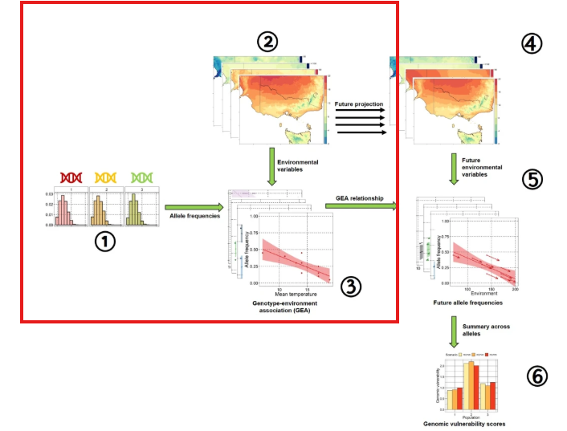

**1. Opis danych do wykonania ćwiczeń**

Na poprzednich zajęciach szukaliśmy SNP związanych z adaptacją do klimatu metodami pośrednimi, na postawie ich wzorców zmienności i związku ze strukturą populacji. Celem dzisiejszych zajęć będzie wykrywanie SNP które **bezpośrednio** związane są z odpowiedzią na czynniki środowiskowe w literaturze określane jako *genotype–environment association* (GEA). W istocie podejścia GEA szukamy alleli, których częstość jest statystycznie skorelowana ze zmiennością środowiskową w badanych populacjach. Jedną z najczęściej stosowanych technik jest **analiza redundancji (RDA)**, która jest szczególnie skuteczna w wykrywaniu zależności obejmujących jednocześnie wiele alleli i wiele zmiennych środowiskowych. RDA pozwala na jednoczesną regresję wielu zmiennych zależnych (częstości alleli) na wiele zmiennych objaśniających (zmienne środowiskowe), w celu wyłonienia tych SNP, których częstości alleli można w sposób liniowy wyjaśnić za pomocą składowych opisujących środowisko.

O użyciu RDA w ww. kontekście więcej przeczytasz tu:

https://besjournals.onlinelibrary.wiley.com/doi/full/10.1111/2041-210X.13722

Na dzisiejszych zajęciach **wykonamy kroki 1-3** z powyższego schematu - przygotujemy dane genetyczne i środowiskowe, oraz wybierzemy zestaw SNP skorelowanych ze zmiennością środowiskową. Na kolejnych zajęciach użyjemy tych SNP do **prognozowania niedopasowania genetycznego** do klimatu w przyszłości (4-6).

Dane z którymi Państwo pracują pochodzą z publikacji *Adaptive potential and genomic vulnerability of keystone forest tree species to climate change: a case study in Scots pine* która jest w recenzji w czasopiśmie Evolutionary Applications. Dane pochodzą z sekwencjonowania SNP-chip przy użyciu płytki Axiom-Pine GAP osobników sosny zwyczajnej w gradiencie środowiskowym z Finlandi do Polski.

Dane te są już po QC - surowe dane opracowywane są przy użyciu Axiom Suite Anlysis, a QC wykonany został w PLINK - gdzie wyeksportowany został plik .map i .ped. Państwo otrzymują już plik w formacie **genind** z adegenet w R - zapisany jako RDS (natywny format zapisu obiektów w R).

## Struktura genetyczna populacji sosny

```r
#Install and load required packages (installation lines are commented out assuming packages installed)

# install.packages("BiocManager")
# For Bioconductor package installation if needed

# install.packages("remotes")
# install.packages(c("vcfR", "pcadapt", "qvalue", "ggplot2"))
# BiocManager::install("qvalue")
# remotes::install_github("whitlock/OutFLANK")
# Install OutFLANK from GitHub`
# Install ggvegan z github
# remotes::install_github("gavinsimpson/ggvegan")


# Load libraries
```

```r
# Load necessary libraries
packages <- c("vcfR", "pcadapt", "qvalue", "OutFLANK","ggVennDiagram",  "ggplot2", "pegas", "adegenet", "poppr", "ggpubr", "rnaturalearth", "rnaturalearthdata", "geodata", "terra", "psych", "adespatial","vegan", "ggvegan", "dplyr")
#librarises

lapply(packages, require, character.only = TRUE)
```

W tym kroku wczytujemy obiekt `genind` z zapisanymi danymi genetycznymi w formacie RDS oraz metadane populacji. Obiekt `genind` to podstawowa klasa w pakiecie **adegenet**, która przechowuje informacje o genotypach wielu osobników i loci.

```r
# Usatw working directory do folderu z danymi

# Wczytaj obiekt RDS
genind_pines <- readRDS("GENIND_data")

# wczytaj metadane - na poziomie populacji
meta_pops <- read.csv() # ustaw odpowiedni plik

# analogicznie na poziomie osobniczym
... <- read.csv()


# sprawdź metadane - jakie są  akronimy regionów?
# wykorzystamy je do ustawienia kolorów do wizuaizacji

# Kolory do wizualizacji - skorzystamy z named vector - wtedy zawsze dany kolor będzie odpowiadał tej kategorii

# jeśli chcesz - wybierz inne kolory, pamiętaj by zamiast XXX wybrać odpowiedni akronim regionu
kolory <- c("XXX" = "#b8a684", "XXX" = "#46BDD4", "XXX" = "#D0EB34")


# Sprawdź i zanotuj w raporcie - liczbę loci, liczbę osobników, liczbę populacji, liczbę osobników na populację
```

Sprawdzimy rozmieszczenie naszych populacji na mapie - jaki gradient geograficzny reprezentują nasze dane? Odtworzymy poniższą mapę:

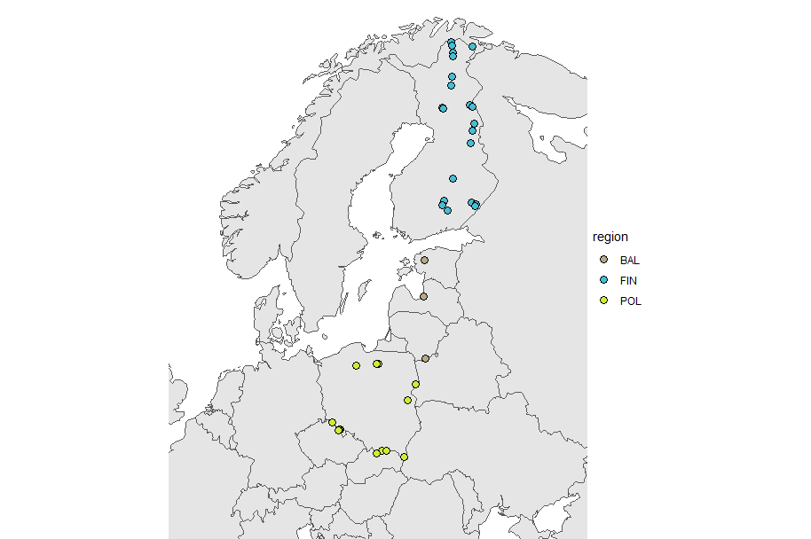

```r
# przygotowanie mapy
# funkcja ne_contries() z pakietu rnaturalearth pobierze mapę świata jako wielokąty (polygons)
world <- ne_countries(scale = "medium", returnclass = "sf")


# do wizualzacji używamy składni ggplot
#
ggplot(data = world) +
  geom_sf() +
  theme_void()

# nasze zadanie polega na dodaniu punktów i przycięciu mapy do zakresu naszego gradientu

ggplot(data = world) +
  geom_sf() +
  geom_point(data = meta_pops, aes(x = XXX, y = XXX, fill = XXX), size = 3, shape = 21) +
  # ustaw odpowiednio x, y i fill z ramki meta_pops
  coord_sf(xlim = c(X, X), ylim = c(Y, Y), expand = F)+
  # ustaw odpowiednie limity - jaki wycinek mapy chcesz przedsawić? Spróbuj kilku wartoći
  scale_fill_manual(values = kolory)+
  theme_void()
```

**Zajrzyj po koordynaty - jeśli utknąłeś**

```r
coord_sf(xlim = c(0, 40), ylim = c(45, 72), expand = F)
```

Zanim wykonamy anzlizę RDA sprawdzimy, czy nasz populacje posiadają wyraźną strukturę genetyczną, zwizaną z rozmieszczeniem geograficznym.

```r
# PCA (a także później RDA) wymaga danych bez braków. Wykonujemy imputację danych średnią

data_no_NA = adegenet::tab(genind_pines, NA.method = "mean")

# Perform PCA
pca = dudi.pca(data_no_NA, scannf = FALSE, scale = T, nf = 3,center = T)

# obiekt pca ma zapisane koordynaty osobników w układzie współrzędnych PC1 i PC2
# pca$li
# do pokolorowania punktów wg regionów potrzebujesz wektora region na poziomie osobniczym
# sprawdź w metadanych :)

# stwórz ramkę która wykorzystasz do wizualazacji pca jako scatterplot w ggplot

pca_df <- data.frame(PC1 = XXX, PC2 = XXX, region = YYY)


ggplot(pca_df, aes(x = PC1, y = PC2, fill = region))+
  geom_point(shape = 21, size = 3)+
  scale_fill_manual(values = kolory)+
  theme_pubr()
```

**Zajrzyj jeśli utknąłeś**

```r
pca_df <- data.frame(PC1 = pca$li[,1], PC2 = pca$li[,2], region = region_ind)

ggplot(pca_df, aes(x = PC1, y = PC2, fill = region))+ geom_point(shape = 21, size = 3)+ scale_fill_manual(values = kolory)+ theme_pubr()
```

**Zadanie 1**– Wykonaj wizualizację geograficznego rozmieszczenia badanych populacji. Podaj liczbę badanych populacji, akronimy regionów, liczbę loci, liczbę osobników,liczbę osobników na populację. Wykonaj analzię PCA i odpowiedz na pytanie - czy struktura genetyczna populacji koresponduje z rzomieszczeniem geograficznym?. Zamieść uzyskane ryciny w raporcie.

## RDA - przygotowanie danych genetycznych

W analizie RDA jako zmienne zależne będziemy wykorzystywać częstości alleli w każdej populacji. Obliczymy częstość alleli funkcją rraf() z pakietu `poppr`. Dla każdego SNP otrzymujemy dwie kolumny (częstość allelu „1” i „2”), ale ponieważ $p+q=1$, wystarczy zachować tylko jedną (np. pierwszą z każdej pary). Liczenie częstości zajmie około 5 min - by zachować wynik - zapiszemy go jako plik RDS.

```r
allele_freqs = data.frame(rraf(genind_pines, by_pop=TRUE, correction = FALSE), check.names = FALSE)
# zachowujemy częstość pierwszego allelu z pary
allele_freqs = allele_freqs[, seq(1, dim(allele_freqs)[2], 2)]
# sprawdź zawartość naszej ramki
allele_freqs[1:10,1:10]

# zapisujemy częstości alleli
saveRDS(allele_freqs, file = "allele_freqs")
```

```
##        DHN2_2_396_C.C 2_10502_01_4_921_A.A 0_17790_1_3_783_T.A
## FIN_13      0.4000000            0.5000000           0.5555556
## FIN_12      0.6111111            0.3500000           0.5000000
## FIN_4       0.3461538            0.4545455           0.4615385
## FIN_14      0.4500000            0.7000000           0.6000000
## FIN_15      0.4375000            0.6666667           0.7222222
```

## RDA - przygotowanie danych środowiskowych

W analizie GEA zmienne środowiskowe stanowią macierz predyktorów. Skorzystamy wyłącznie ze zmiennych bioklimatycznych z bazy WorldClim (19 zmiennych „bio”) - https://www.worldclim.org/data/bioclim.html. Zmienne te są oparte na dwóch podstawowych wartościach - **średnia roczna temperatura i średnie roczne opady**. Pamiętaj, że w uproszczonej wersji analizy używamy wyłącznie tych zmiennych - jednak należałoby uwzględnić wszystke potencjalnie istotne zmienne środowiskowe dla naszego gatunku.

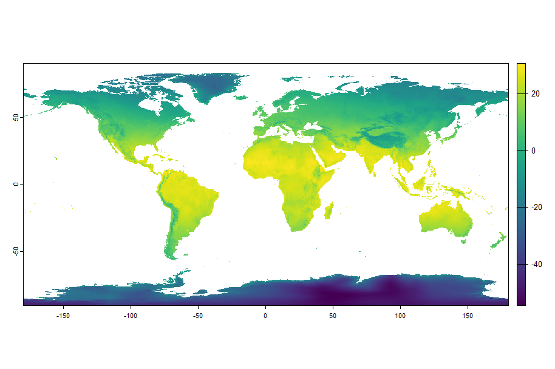

```r
## przygotowanie danych środowiskowych
# worldclim_global z pakietu geodata pobierze zmienne bioklimatyczne

bio_current  <-  worldclim_global(var = 'bio', res = 2.5, path = ".")

# sprawdź strukturę danych - obiekt Spatial Raster - mamy wszystkie warstwy w jednym obiekcie
str(bio_current)
bio_current

# chemy wyciagnąć każdą warstwę do osobnego obiektu w R
for (i in 1:19){
  assign(paste0("bio.", i), bio_current[[i]])
}

# sprawdźmy podstawowy wykres zmiennej bio.1

plot(bio.1)
```

Do naszej analizy RDA potrzebujemy tabeli z wartością zmiennych bioklimatycznych dla populacji - musimy więc wyciąć wartość z rastra dla współrzednych populacji. Wykonamy jednak jeszcze dodatkowo wizuliazację zmienncy bioklimatycznych: **średnia roczna temperatura i średnie roczne opady** by zobaczyć, czy któraś z nich wyraźnie różnicuje nasze populacje.

```r
# Sprawdź na stornie bazy worldclim i wybierz do wizualziacji zmienną średnia roczna temperatura i średnia wartość opadów

# Chemy przedstawić naszą mapę bazową z populacjami i raster. Najprostszą opcją jest przeskztałcenie rastra na ramkę danych i wizualizacja w ggplot


# Przycinamy raster do zasięgu jak w naszej mapie bazowej

r_crop_1 <- crop(bio.X, ext(X1, X2, Y1, Y2)) # wartości ext - takie same jak w coord_sf
# bio.X - zamień na odpwoednią dla zmiennej temp
# 2. Turn it into a tidy data.frame
r_df_1 <- as.data.frame(r_crop_1, xy = TRUE) %>%
  rename(bioX = wc2.1_2.5m_bio_X) # zamień nazwę na odpowiednią (zgodną z wybraną zmienną bioclim)


## wykonaj analogiczne kroki dla zmiennej związanej z opadami


# Wizualizacja w ggplot

# TEMP

ggplot(data = world) +
  geom_raster(data = r_df_1,
             aes(x = x, y = y, fill = bio1)) +
  scale_fill_viridis_c(name = "Annual mean temp",option = "A") +
  geom_sf(fill = NA, col = "black", size = 2) +
  geom_point(data = map_df, aes(x = lon, y = lat), size = 3) +
  coord_sf(xlim = c(0, 40), ylim = c(45, 72), expand = FALSE)+
  theme_void()

# PRECIPITATION

ggplot(data = world) +
  geom_raster(data = r_df_2,
              aes(x = x, y = y, fill = bio12)) +
  scale_fill_viridis_c(name = "Annual precipitation") +
  geom_sf(fill = NA, col = "black", size = 2) +
  geom_point(data = map_df, aes(x = lon, y = lat), size = 3) +
  coord_sf(xlim = c(0, 40), ylim = c(45, 72), expand = FALSE)+
  theme_void()
```

**Zajrzyj jeśli utknąłeś**

```r
# cropping raster to our extent for bio1
r_crop_1 <- crop(bio.1, ext(0, 40, 45, 72))
# 2. Turn it into a tidy data.frame
r_df_1 <- as.data.frame(r_crop_1, xy = TRUE) %>%
  rename(bio1 = wc2.1_2.5m_bio_1)

# cropping raster to our extent for bio12
r_crop_2 <- crop(bio.12, ext(0, 40, 45, 72))
# 2. Turn it into a tidy data.frame
r_df_2 <- as.data.frame(r_crop_2, xy = TRUE) %>%
  rename(bio12 = wc2.1_2.5m_bio_12)


# TEMP

ggplot(data = world) +
  geom_raster(data = r_df_1,
             aes(x = x, y = y, fill = bio1)) +
  scale_fill_viridis_c(name = "Annual mean temp",option = "A") +
  geom_sf(fill = NA, col = "black", size = 2) +
  geom_point(data = map_df, aes(x = lon, y = lat), size = 3) +
  coord_sf(xlim = c(0, 40), ylim = c(45, 72), expand = FALSE)+
  theme_void()

# PRECIPITATION
ggplot(data = world) +
  geom_raster(data = r_df_2,
              aes(x = x, y = y, fill = bio12)) +
  scale_fill_viridis_c(name = "Annual precipitation") +
  geom_sf(fill = NA, col = "black", size = 2) +
  geom_point(data = map_df, aes(x = lon, y = lat), size = 3) +
  coord_sf(xlim = c(0, 40), ylim = c(45, 72), expand = FALSE)+
  theme_void()
```

Pozostało nam jedynie stworzyć i zapisać ramkę danych z zmiennymi środowiskowymi dla lokalziacji naszych populacji. Najpierw przekształcamy nasze koordynaty na ramkę danych **sf** - dodajemy informację o typie projekcji na mapie (zgodniej z projekcją naszej mapy i rastra). Wykorzyujemy standardowej projekcji w systemie GPS (spotkasz go na mapach Google Earth) **WGS84.** Odpowiada mu kod **crs 4326.**

```r
meta_pops_sf <- st_as_sf(meta_pops, coords = c("lon", "lat"), crs = 4326)
# wycinamy wartości dla tych współrzędnych z rastra
env_df <- terra::extract(bio_current, meta_pops_sf)[, -1] # w finalnej ramce pozbywamy się pierwszej kolumny

# zmieniamy nazwy w ramce na bio1 - bio19 (domyślnie mają nazwy jak w rastrze np. c2.1_2.5m_bio_1)
names(env_df) <- paste0("bio", 1:19)

# zapisz powstałą ramkę - będziemy z niej korzystać na kolejnych zajęciach!

saveRDS(env_df,file = "env_df")
```

**Zadanie 2**– Wykonaj wizualizację średniej rocznej temperatury i średniych rocznych opadów w badanym gradiencie. Zamieść uzyskane ryciny w raporcie. Na podstawie wizualizacji odpowiedz, która zmienna ma większy wpływ na róznicowanie populacji?

## RDA - właściwa analiza i szukanie outlierów

Pierwszym krokiem analizy jest sprawdzenie korelacji między zmiennymi. Metoda ta jest jest czuła na silne korelacje naszych predyktorów - najlepszą opcją jest usunięcie zmiennych |r| > 0.7.

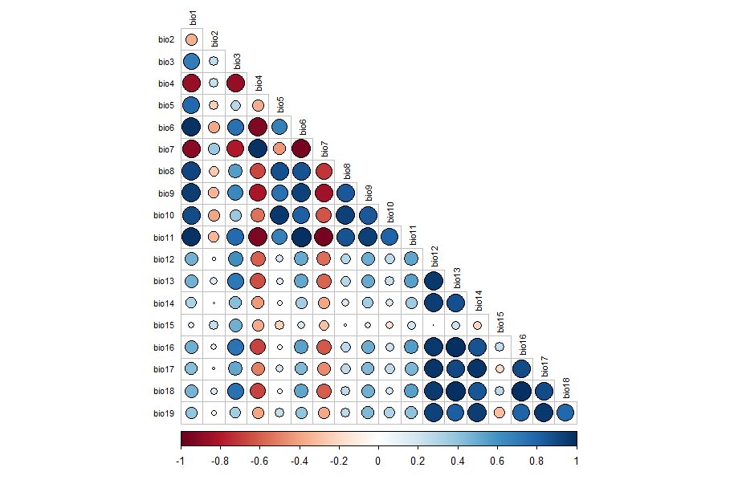

```r
cor_env <- cor(env_df)
corrplot(corr = cor_env, type = "lower", diag = F, outline = T,tl.cex = 0.7,tl.col = "black")

# sprawdź na corrplot poziom korelacji zmiennych, wybierz zmienne związaną z temp, precip i te które nie mają wysokiego współczynnika korealcji
```

```r
# wybierz do ramki danych env_df_final tylko te zmienne

env_df_final <- env_df[,c(X,X,X,X)]
cor_env_1 <- cor(env_df_final)
corrplot(corr = cor_env_1, type = "lower", diag = F, outline = T,tl.cex = 0.7,tl.col = "black", method = "number")
# nadaj zmiennym nazwy będące akronimem
names(env_df_final) <- c("mean_t", "XXX", "XXX", "XXX")
```

**Zajrzyj jeśli utknąłeś**

```r
env_df_final <- env_df[,c(1,2,12,15)]
names(env_df_final) <- c("mean_t", "mean_dry", "prec", "sesonal")
```

Sam kod na wykonanie RDA jest prosty. Wymagane jest jedynie to, by nasza matryca częstości alleli nie miała braków.

```r
sum(is.na(allele_freqs)) # ile braków

allele_freqs_noNA <- allele_freqs %>%
  mutate(across(everything(), ~ ifelse(is.na(.), mean(., na.rm = TRUE), .)))
# zamiana na średnią częstość wartości na


pine.rda <- rda(allele_freqs_noNA ~ ., data=env_df_final, scale=T)

pine.rda
# jaka część zmienności genetycznej jest wyjaśniania przez nasz model - tj 4 zmienne środowiskowe?
RsquareAdj(pine.rda)
```

Nasza analiza miała za zadanie odpowiedzieć na pytanie - jaka część zmienności genetycznej w naszych danych może być wyjaśniona przez kombinację czynników środowiskowych - w naszym wypadku **to ~ 5%**. Skąd taka mała wartość? Nie jest ona zaskoczeniem - spodziewamy się, że tylko niewielka część SNP związanych jest z adaptacją a reszta jest neutralna, zastem **które ze naszych SNP** są najpewniej zwiazane ze zmiennymi środowiskowymi i co ważniejsze, **z jakimi zmiennymi**?

W analize RDA podobnie jak w PCA - zmienność danych (częstości alleli) jest wyjaśniana przez osie RDA (liniowe kombinacje naszych predyktorów - zmiennych środowiskowych). Nie wszystkie osie muszą być informatywne - tzn istotnie statystycznie związane z zmiennością danych (SNP). Związek każdego SNP z osią RDA opisuje jego loading - za outliery uznamy te SNP, które są związane z istotną statystycznie osią RDA, mają skajnie niskie lub wysokie loadings.

```r
# Podobnie jak w PCA - nieformalnie na ocenę ile osi RDA wyjaśnia najwięcej zmienności
# możemy użyć screeplot
screeplot(pine.rda)

# istnieje formalny sposób oceny istotnej osi RDA i tej którą zostaiwmy do poszukiwania outlierów
# ale jest ona długotrwała (a wynik zbieżny - w tym przypadku, z oceną na oko)

# DLA CIEKAWYCH - NIE WYKONUJ NA ZAJĘCIACH
## signif.axis <- anova.cca(pine.rda, by="axis", parallel=getOption("mc.cores"))
##signif.axis


load.rda <- scores(pine.rda, choices=c(1), display="species")
# loadings SNP dla istotnej RDA - w naszym przypadku RDA1
hist(load.rda[,1], main="Loadings on RDA1")

# nasze SNP outlierowe to te, które znajdują się na skraju rozkładu - za takie uznamy SNP więcej niż 2.5 odchylenia standardowe od średniej

source(file = "RDA_outliers_finder.R") # custom written function

cand0 <- find_outlier_snps(load.rda[,1], allele_freqs_noNA, z = 2.5)
cand_final <- annotate_snps_with_env(cand0, allele_freqs_noNA, env_df_final)
outliers_RDA <- cand_final$SNP_pos
```

Na tym wykresie widzisz **wyniki RDA przedstawione jako wykres biplot** – każdy punkt to populacja, pokolorowana według regionu (BAL, FIN, POL). Strzałki oznaczają wektory zmiennych środowiskowych. **Oś RDA1 (pozioma)** to główna oś skorelowana ze zmiennością genetyczną i gradientem środowiskowym – tu przede wszystkim z temperaturą. Populacje przesunięte w prawo mają genotypy odpowiadające wyższym temperaturom. Z testów permutacyjnych (w naszym przypadku screeplot) wynika, że **tylko oś RDA1** jest istotna statystycznie. Oznacza to, że gradient temperatury wyjaśnia część struktury genetycznej w sposób większy niż losowa permutacja danych. W tym wypadku spodziewamy się liniowej zależnośći częstości alleli z zmienną środowiskową!

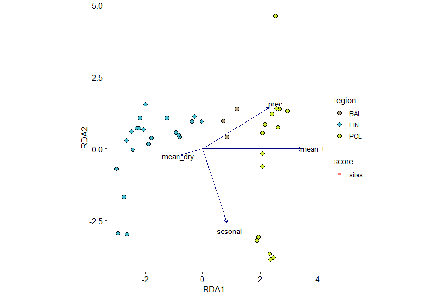

```r
# ploting RDA - default and ugly plot
plot(pine.rda, scaling=3)


### using ggvegan - not perfect but simple


site_scores <- scores(pine.rda, display = "sites", scaling = 3)
sites_df <- as.data.frame(site_scores)
sites_df$region <- meta_pops$region

# Make the base ggplot from the RDA
p <- autoplot(pine.rda, scaling = 3,
              axes = c(1, 2),
              layers = c("sites", "biplot"),
              geom = "point") +
  geom_point(data = sites_df, aes(x = RDA1, y = RDA2, fill = region), shape = 21, size = 3, color = "black") +
  scale_fill_manual(values = kolory)+
  theme_pubr(legend = "right")

# Show plot
p
```

**Zadanie 3**– Wykonaj analizę RDA i zaraportuj liczbę SNP outlierowych wykrytych tą metodą. Zamieść wszystkie uzyskane ryciny w raporcie. Z którą zmienną środowiskową zwiazane są SNP uznane za outilerowe?

Ponieważ nigdy nie powinniśmy ufać wynikom **jednej analizy** i aby ocenić jedncześnie **siłę sygnału lokalnej adaptacji** - porównamy liczbę outlierów uzyskanych za pomocą RDA i metod poznannych na poprzednich zajęciach **(pcadapt, outflank)**.

**Zadanie 4**– Wykonaj analizę pcadpt i outflank dla naszych danych. Zaraportuj wyłącznie liczbę SNP outlierowych uzyskanych tymi metodami, wykonaj wykress Venn dla porównania trzech metod - RDA, pcadpt i outFLANK. Wybierz SNP które są wspólne dla 3 metod jako outliers_final.

```r
### Jako input file do pcadpt możemy użyć matrycy genotypów w formacie tzw. allelic dosage - genotypy zakodowane jako 0, 1 i 2. Układ SNP x IND (rzędy - SNP, kolumny IND)

## skorzystaj z pliku wczytaj plik allelic_dosage - zapisany jako RDS

allelic_dosage <- readRDS(file = "allelic_dosage_pines")
pcadapt_in <- read.pcadapt(input = t(allelic_dosage)) # wykonaj transpozycje - plik allelic dosage to matryca IND x SNP

### w przypadku outFLANK
outflank_input <- allelic_dosage

# zamiana NA na 9
outflank_input[is.na(outflank_input)] <- 9

# matryca zakodowana poprawnie do analizy!

##  POWODZENIA!
```